# Activity: Base R

Alvin Chen

June 23, 2023

### Question 1: Subsetting

#### Select the element in 10th row and 5th column in `iris` dataset

```r
data(iris)

iris_element <-
  iris[10, 5] # 10th row 5th column

print(iris_element)
```

```
[1] setosa
Levels: setosa versicolor virginica
```

```r
selected_column <-
  iris$Petal.Width # select column in data set

last_five_rows <-
  tail(selected_column, 5) # get last 5 rows

print(last_five_rows)
```

```
[1] 2.3 1.9 2.0 2.3 1.8
```

#### What is the average Sepal Length of flowers with Petal widths greater than 1?

```r
greater_than_one <-
  subset(iris, Petal.Width > 1) # get petals greater than 1

mean_sepal_len <-
  mean(greater_than_one$Sepal.Length) # get mean of speal length that match cond.

print(mean_sepal_len)
```

```
[1] 6.325806
```

### Question 2: For Loops

#### Write a `for` loop that iterates over the numbers 1 to 10. If the number less than 5 print the multiple of 3 (multiply the number by 3), and if the number is greater than or equal to 5 print the multiple of 2 (multiply the number by 2).

```r
for (i in 1:10) { # iterate through 1 to 10
  if (i < 5) { # if less than 5
    i = i * 3 # multiply num by 3
  } else { # if 5 or greater
    i = i * 2 #multiply by 2
  }
  print(i) # print out i
}
```

```
[1] 3
[1] 6
[1] 9
[1] 12
[1] 10
[1] 12
[1] 14
[1] 16
[1] 18
[1] 20
```

### Question 3: While loops

#### Write a `while` loop that prints out random normal numbers with mean equal 1 and standard deviation 2 (use rnorm()) but stops (breaks) if you get a number bigger than 3. Do not change the value inside set.seeed.

```r
set.seed(184)

while (TRUE) {
  ran_norm <- rnorm(1, mean = 1, sd = 2)
  print(ran_norm)

  if (ran_norm > 3) {
    break
  }
}
```

```
[1] 0.1167419
[1] 1.588951
[1] 2.436941
[1] 0.932507
[1] 2.408507
[1] -1.206123
[1] -1.158457
[1] 4.96388
```

### Question 4: for loops in data tables

#### Use a nested for loop that produces the following data frame. Name the dataframe `Counting` and the variables (columns) V1, V2, V3, and V4. (There are 3 loops).

Hint: First identify the pattern(s) in the table before you create the for loop.

| V1 | V2 | V3 | V4 |
| --- | --- | --- | --- |
| 1 | 2 | 3 | 4 |
| 2 | 3 | 4 | 5 |
| 3 | 4 | 5 | 6 |

```r
Counting <- data.frame(V1, V2, V3, V4) # make data frame

for (i in 1:4) {  # for loop 1
  for (j in 2:5) {  # for loop 2
    for (k in 3:6) {  # for loop 3
      V1 = c(i, j, k) - 3  # v1 numbers
      V2 = c(i, j, k) - 2  # v2 numbers
      V3 = c(i, j, k) - 1  # v3 numbers
      V4 = c(i, j, k)  # v4 numbers
    }
  }
}

print(Counting) # print dataframe
```

[output not shown]

```r
NA
```

### Question 5: user defined functions

#### 5A) Complete the following user define function to generate `n` random normal numbers with a given mean and standard deviation and plot a histogram of it. Do not change the seed number in set.seed. You can use the function `hist` to plot the histogram.

##### 5B) Then call the function to generate 1000 random normal numbers with mean 0 and standard deviation 1 and plot a histogram of it.

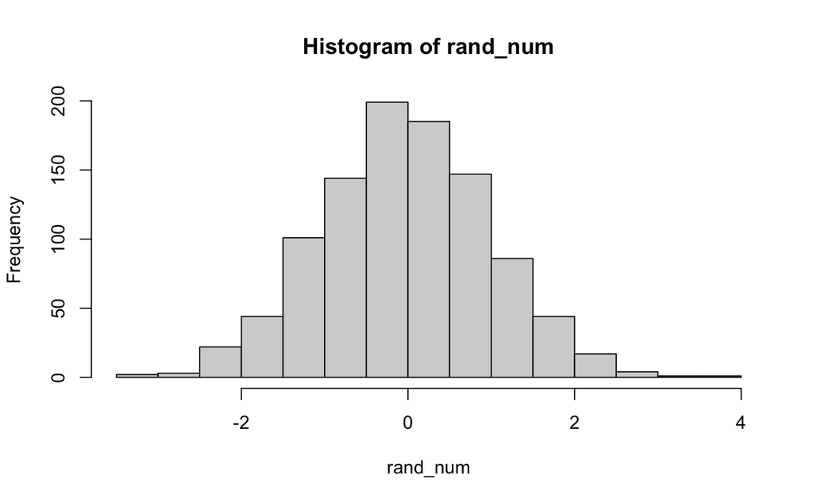

```r
set.seed(184)
plotNormal <- function(repitions, mean, sd){
  rand_num <- rnorm(repitions, mean = mean, sd = sd) # generate random numbers

  hist(rand_num)
}

plotNormal(1000, mean = 0, sd = 1) # call function with given parameters
```

##### Extra Credit:

Repeat parts 5A and 5B, and add

1. A title that say “Histogram from a Normal(`mean`, `sd`) Distribution”, but the user given values of `mean` and `sd`.
2. an argument to change the color of the histogram.

Call the function to generate 1000 random normal numbers with mean 0 and standard deviation 1 and plot a histogram. Make the bins blue.

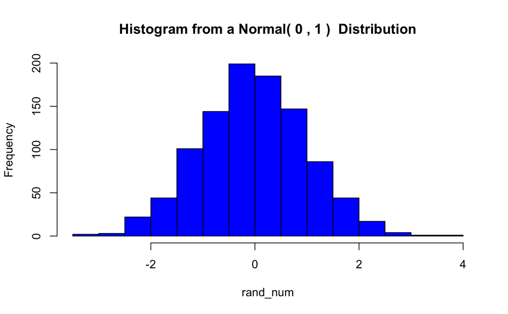

```r
set.seed(184)
plotNormal <- function(repitions, mean, sd, color){
  rand_num <- rnorm(repitions, mean = mean, sd = sd) # generate random numbers
  # add a title with the given instructions
  hist(rand_num, main = paste("Histogram from a Normal(", mean, ",", sd, ")", " Distribution"), col = color)
}

plotNormal(1000, mean = 0, sd = 1, color = "blue") # call function with given parameters
```

```r
NA
NA
```